# Firefighter

Yoni

2/13/2022

# Intro

The goal of this portfolio is to try to find up weather firefighters gain more wage for more work, in general. As a result of the global warming, wildfires became more common all over the US.

One can ask, should the work of emergency, ans specifically firefighters, be paid by the amount of cases?

Here are some pros and cons:

Pros:

- Harder workers get paid better
- Prevent inflation in work conditions cause by cases
- Appealing workers when the are needed the most (in our case- desertification)

Cons:

- Morel Hazard against preventing emergency cases
- Encouraging of splitting cases “on paper”
- Cause unpredictable salary

The method is using data from the API fo [Data USA](https://datausa.io/profile/soc/firefighters), and comparing it to available data about wildfires. We will see that although the sample is too small, some information can be found.

so let’s get started with the libraries:

# Set data

```r
library(easypackages)
#tools
libraries('httr','jsonlite','XML')
libraries('dplyr','tidyr')
#visuals
libraries('ggplot2','ggpubr','knitr')
```

## Wage data importing

This is firemen’s salary from [Data USA](https://datausa.io/profile/soc/firefighters)

```r
wage_rl<-
  "https://datausa.io/api/data?PUMS%20Occupation=332011&drilldowns=PUMA&measure=Average%20Wage,Average%20Wage%20Appx%20MOE,Record%20Count&Record%20Count>=5"
get_fire<- GET(wage_rl)
my_content<- content(get_fire, as= 'text', encoding = "UTF-8")
my_Json<- fromJSON(my_content)
open_fire <- glimpse(my_Json )
```

```r
df_fire<- open_fire$data %>%
  select(c(2,4:7)) %>%
  mutate(Year= as.numeric(Year)) %>%
  rename(Average_Wage= 'Average Wage') %>%
  rename('Mean Wage Appx MOE' = 'Average Wage Appx MOE') %>%
  mutate(log_Wage= log(Average_Wage) )

AB<- function(vec) #function to make "Dothan City PUMA, AL" to "AL"
  {split<- rev(strsplit(vec, ", ")[[1]] )
  return(as.vector (split[1]) ) }

df_fire$US_code<- as.character(unlist (lapply(df_fire$PUMA, AB)) )
```

Here you can see the data splitted by year and states

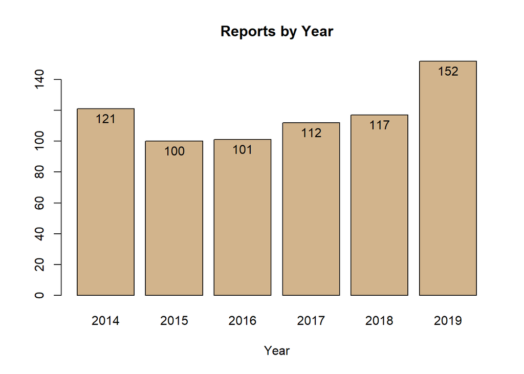

```r
pres_yir<- table(df_fire$Year) #add to bar plot

{bp<- barplot(table(df_fire$Year), col = "tan", main = 'Reports by Year', xlab = 'Year')
#grid(nx= NA, ny= NULL)
text(bp,pres_yir-6,labels = pres_yir)}
```

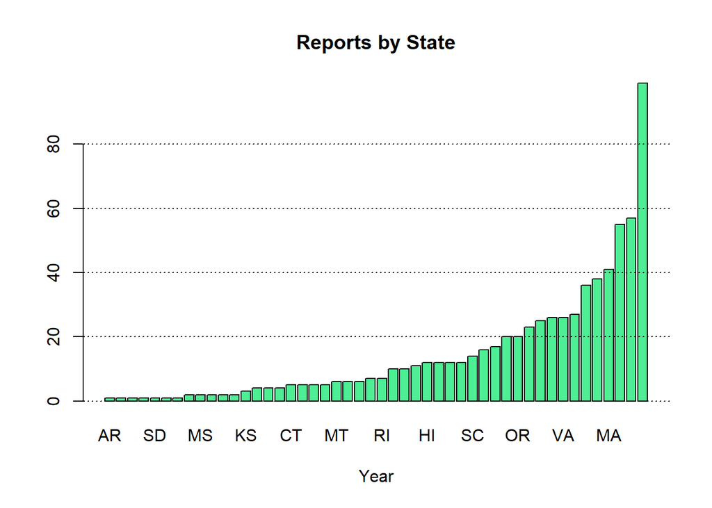

```r
df_fire<- df_fire %>%
  mutate(US_code=replace(US_code, US_code=="TX (79500US4805905)", "TX")) #bug fixing

{bp<- barplot(sort(table(df_fire$US_code)), col = "seagreen2", main = 'Reports by State', xlab = 'Year')
grid(nx= NA, ny= NULL, col = "black")}
```

### Wiki coder

We are using Wikidata to import [key](https://www.wikidata.org/wiki/Wikidata:Lists/US_states) from 2- letters to state name.

```r
wiki_get<- GET('https://www.wikidata.org/wiki/Wikidata:Lists/US_states')
wiki_contnt<- content(wiki_get, "text")
wiki_state<- readHTMLTable(wiki_contnt, trim=T, as.data.frame=T, header= T)
wiki_state<-bind_rows(wiki_state)

wiki_state<- wiki_state[-(1:2),] %>%
  select(V1:V3) %>%
  drop_na(V2) %>%
  `colnames<-`(c("State","US_code","Instance_of"))

kable(wiki_state[1:4,1:2])
```

| State | US_code |
| --- | --- |
| Alaska | AK |
| Alabama | AL |
| Arkansas | AR |
| Arizona | AZ |

```r
df_fire <- merge(df_fire,wiki_state,by="US_code")
rm(wiki_contnt,wiki_state)
rm(my_content, my_Json, open_fire)
```

### Download Automation

The data been taken from the [Insurance Information Institute](https://www.iii.org/table-archive/23284)

You can updated data to 2021 here, but the imported data from Data USA reach only 2019.

```r
call_fire<- function(x,year, m_TF= T)
  {
  my_get<- GET(x)
  my_content<- content(my_get, as= 'text', encoding = "UTF-8")
  pre_df<- readHTMLTable(my_content, trim=T, as.data.frame=T, header=m_TF)
  if(m_TF)
  {bind_df<- bind_rows(pre_df)[4:6]} else {bind_df<-pre_df[[3]]}
  names(bind_df)<- c('State','fires_Num','Num_acres_burned')
  the_df<- bind_df[!is.na(bind_df$State),]
  the_df<- the_df[!duplicated(the_df[,'State']),] #delete duplicate states
  the_df$Year<- year #year parameter for future combine
  return(the_df)
  }
```

```r
df_14<- call_fire("https://www.iii.org/table-archive/214725/file", 2014)
df_15<- call_fire("https://www.iii.org/table-archive/218674/file", 2015)
df_16<- call_fire("https://www.iii.org/table-archive/220226/file", 2016)
df_17<- call_fire("https://www.iii.org/table-archive/220932/file", 2017)
df_18<- call_fire("https://www.iii.org/table-archive/221865/file", 2018, F)[-1,] #bug fixing
df_19<- call_fire("https://www.iii.org/table-archive/222809/file", 2019)

no_coma<- function(x) #from character"12,345" to numeric 12345
  {as.numeric(gsub(",","", x))}

firelist<- rbind(df_14,df_15,df_16,df_17,df_18,df_19) %>%
  mutate(fires_Num=replace(fires_Num, fires_Num=="(1)", 0)) %>%
  mutate(Num_acres_burned=replace(Num_acres_burned, Num_acres_burned=="(1)", 0)) %>%
  mutate(Num_acres_burned= no_coma(Num_acres_burned))%>%
  mutate(fires_Num= no_coma(fires_Num))
# merge & head
fire_full<- (merge(firelist, df_fire, by= c("State", "Year"))) %>%
  select(-c(9,11))
```

Here are some rows from the data I combined

```r
kable(fire_full[sample(1:600,4),], digits = 2,row.names = F, align = 'c')
```

| State | Year | fires_Num | Num_acres_burned | US_code | PUMA | Average_Wage | Mean Wage Appx MOE | log_Wage |
| --- | --- | --- | --- | --- | --- | --- | --- | --- |
| Illinois | 2014 | 36 | 727 | IL | Ashburn, Washington Heights, Morgan Park & Beverly PUMA, IL | 106602.62 | 34672.95 | 11.58 |
| California | 2014 | 7865 | 555044 | CA | Petaluma, Rohnert Park & Cotati Cities PUMA, CA | 83088.18 | 21512.52 | 11.33 |
| South Carolina | 2017 | 1092 | 11041 | SC | Summerville Town & Ladson PUMA, SC | 58152.49 | 47676.63 | 10.97 |
| South Carolina | 2019 | 992 | 5939 | SC | Charleston City PUMA, SC | 53005.06 | 10293.18 | 10.88 |

# Overlooking the Data

We saw that the number of reports by country is very Varied. Therefore, in some analyzing I compare the result to the top 6 reported states. we will see that there is also difference in the mean wage. This difference is significant, as we checked it t test.

```
## [1] "California"    "Florida"       "Texas"         "Massachusetts"
## [5] "Washington"    "New York"
```

[output not shown]

```
##
##  Welch Two Sample t-test
##
## data:  fire_full$Average_Wage[full_6] and fire_full$Average_Wage[-full_6]
## t = 4.0351, df = 595.12, p-value = 6.169e-05
## alternative hypothesis: true difference in means is not equal to 0
## 95 percent confidence interval:
##   3966.712 11489.494
## sample estimates:
## mean of x mean of y
##  70298.03  62569.93
```

Here are the progress of acres burned in the us. from a quick look at da data we see that California and Alaska suffer the most from wildfires, and also has the biggest change in wildfires

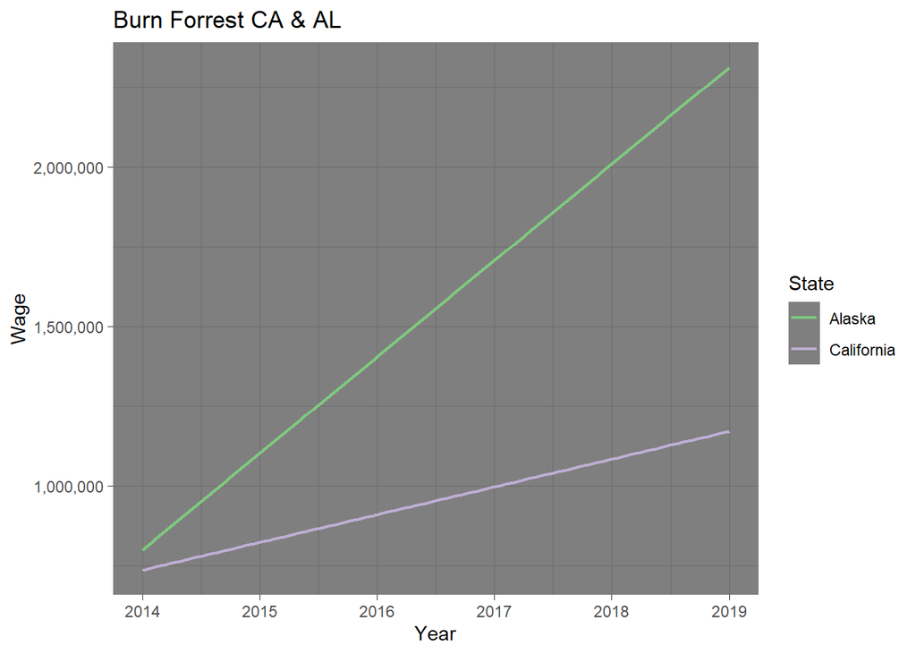

```r
big_2 <- as.vector(count_state[1:6,1])
full_2<- fire_full$State%in% c("California", "Alaska")

fire_full [full_2,]%>%
  ggplot(aes(y= Num_acres_burned,x= Year,colour= State))+
  geom_smooth(size=0.8, method = "lm", se= F)+scale_color_brewer(palette="Accent")+
  labs(title = "Burn Forrest CA & AL", xlab= "Year")+ xlab("Year")+ylab("Wage")+
  theme_dark()+  scale_y_continuous(labels = scales::comma)
```

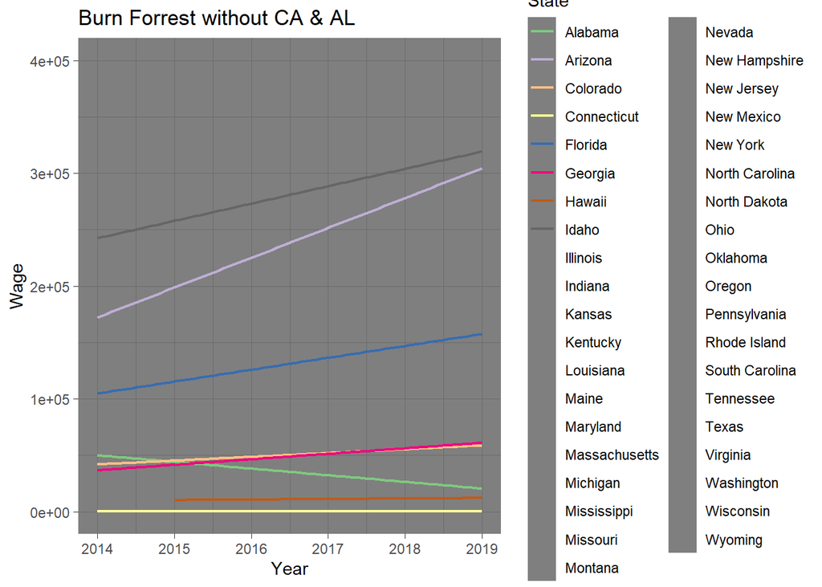

```r
fire_full [(full_2)==0 & fire_full$fires_Num>= 1 ,]%>%
  ggplot(aes(y= Num_acres_burned,x= Year,colour= State))+
  geom_smooth(size=0.8, method = "lm", se= F)+scale_color_brewer(palette="Accent")+
  labs(title = "Burn Forrest without CA & AL", xlab= "Year")+ xlab("Year")+ylab("Wage")+
  theme_dark()+ylim(0,400000) #+scale_y_continuous(labels = scales::comma)
```

Were we can see the distribution of avarage wage of all States & big 6. In addition, tehere is boxplot of the big 6 wages.

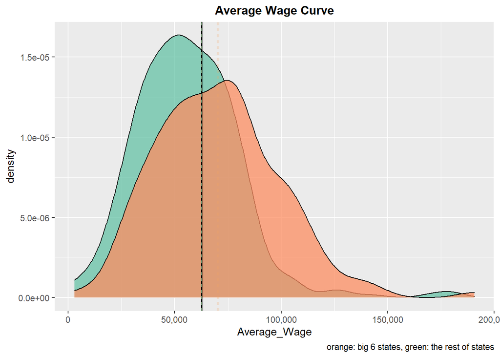

```r
fire_full %>%
  ggplot(aes(x= Average_Wage, fill= full_6))+ scale_fill_brewer(palette="Set2")+
  geom_density(color= "black",position="identity",alpha=0.75 )+
  geom_vline(xintercept= mu_fire,color= "black" ,lty= 1, size= 0.75)+
  geom_vline(xintercept= t.fire$estimate[1], color= "sandybrown",lty= "dashed", size= 0.5)+
  geom_vline(xintercept= t.fire$estimate[2], color= "darkseagreen" ,lty= 'dashed', size= 0.5)+
  labs(title = "Average Wage Curve",caption = "orange: big 6 states, green: the rest of states")+  scale_x_continuous(labels = scales::comma)+theme(legend.position="none")+
  theme(plot.title = element_text(size=12,hjust = 0.5,face = "bold"))#+theme_bw()
```

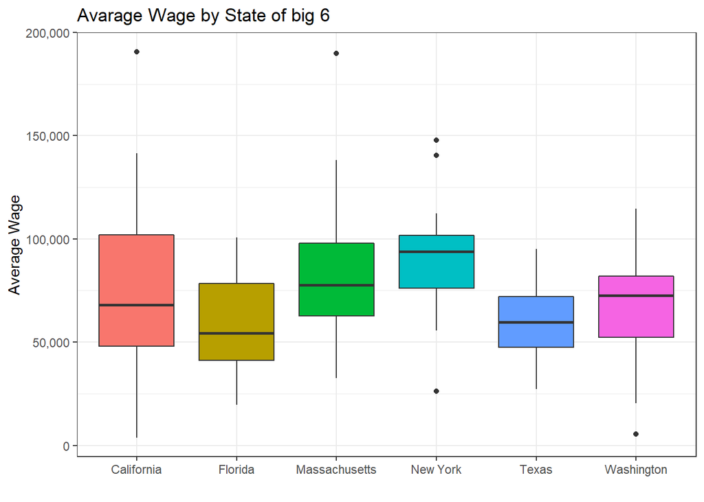

```r
fire_full[full_6,] %>%
  ggplot(aes(y= Average_Wage ,x= State, fill= State))+
  geom_boxplot()+labs(title = "Avarage Wage by State of big 6")+ ylab("Average Wage")+theme_bw()+
  xlab(" ")+scale_y_continuous(labels = scales::comma)+theme(legend.position="none")
```

we see even top 6 reported states are nit homogenize group.

And what about time effect? here we can see

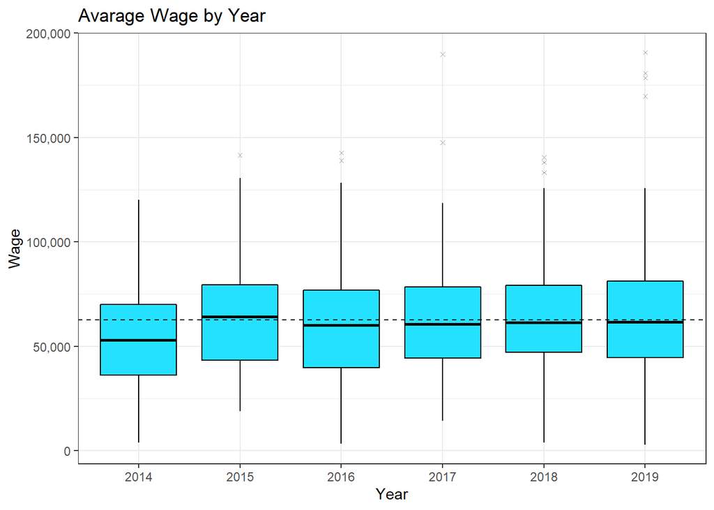

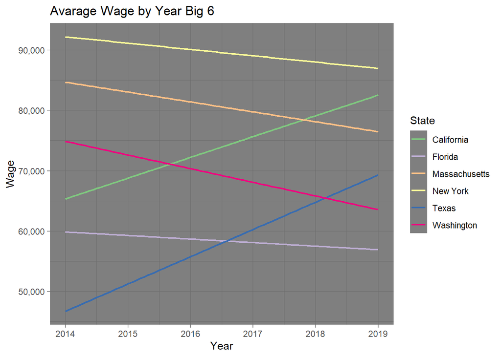

Although there is no visually clear time effect by year, there are some trends. Note that it is might due to different reported stations each year.

Here we will try to see whether there is effect of number of acres burned to average wage. surprisingly, there is none.

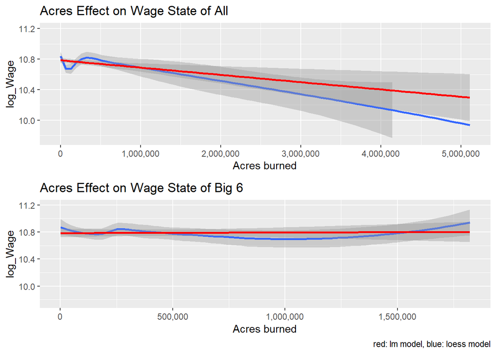

Clearly, there is no positive effect of burned Acres on average wages, and there might be even negative correlation. even though, I do not believe this is causation.

# Models

3 models presented here of predicting the average wage

- lm_year : only year effect
- lm_state: only state effect
- lm_comb : year and state effect

```r
lm_year<- lm(data= df_fire, Average_Wage~ Year)
lm_state<-lm(data= df_fire, Average_Wage~ US_code)
lm_comb<- lm(data= df_fire, Average_Wage~ Year+ US_code)

#anova test to Year effect
anova(lm_state, lm_comb)
```

```
## Analysis of Variance Table
##
## Model 1: Average_Wage ~ US_code
## Model 2: Average_Wage ~ Year + US_code
##   Res.Df        RSS Df  Sum of Sq      F  Pr(>F)
## 1    655 3.6485e+11
## 2    654 3.6030e+11  1 4551573266 8.2619 0.00418 **
## ---
## Signif. codes:  0 '***' 0.001 '**' 0.01 '*' 0.05 '.' 0.1 ' ' 1
```

```r
#anova test to State effect
anova(lm_year , lm_comb)
```

```
## Analysis of Variance Table
##
## Model 1: Average_Wage ~ Year
## Model 2: Average_Wage ~ Year + US_code
##   Res.Df        RSS Df  Sum of Sq     F    Pr(>F)
## 1    701 5.2518e+11
## 2    654 3.6030e+11 47 1.6489e+11 6.368 < 2.2e-16 ***
## ---
## Signif. codes:  0 '***' 0.001 '**' 0.01 '*' 0.05 '.' 0.1 ' ' 1
```

```r
sjPlot::tab_model(lm_comb,lm_year,lm_state, show.ci= F,show.loglik= T, collapse.se = T,
                    dv.labels = c("lm comb","lm year","lm state"))
```

|  | lm comb |  | lm year |  | lm state |  |
| --- | --- | --- | --- | --- | --- | --- |
| Predictors | Estimates | p | Estimates | p | Estimates | p |
| (Intercept) | -2919328.65 (1027441.51) | **0.005** | -2932099.44 (1168633.65) | **0.012** | 33817.84 (7463.38) | **<0.001** |
| Year | 1464.64 (509.55) | **0.004** | 1485.03 (579.49) | **0.011** |  |  |
| US code [AL] | 10593.82 (9467.25) | 0.264 |  |  | 11527.52 (9513.98) | 0.226 |
| US code [AR] | 16507.37 (24626.07) | 0.503 |  |  | 14603.34 (24753.24) | 0.555 |
| US code [AZ] | 22297.64 (8739.63) | **0.011** |  |  | 23210.22 (8782.14) | **0.008** |
| US code [CA] | 39919.30 (7789.29) | **<0.001** |  |  | 40293.59 (7831.26) | **<0.001** |
| US code [CO] | 39776.27 (9092.77) | **<0.001** |  |  | 40362.12 (9140.74) | **<0.001** |
| US code [CT] | 51626.27 (12855.99) | **<0.001** |  |  | 51479.81 (12926.96) | **<0.001** |
| US code [FL] | 23324.98 (8053.90) | **0.004** |  |  | 24273.14 (8091.63) | **0.003** |
| US code [GA] | 11557.81 (8890.90) | 0.194 |  |  | 11373.14 (8939.82) | 0.204 |
| US code [HI] | 31303.55 (10051.65) | **0.002** |  |  | 31840.58 (10105.47) | **0.002** |
| US code [IA] | 9406.76 (24632.39) | 0.703 |  |  | 11896.64 (24753.24) | 0.631 |
| US code [ID] | 10609.89 (10052.53) | 0.292 |  |  | 11268.98 (10105.47) | 0.265 |
| US code [IL] | 49952.98 (8690.09) | **<0.001** |  |  | 50381.53 (8736.85) | **<0.001** |
| US code [IN] | 29363.92 (11589.33) | **0.012** |  |  | 31435.33 (11630.84) | **0.007** |
| US code [KS] | 30259.07 (15450.87) | 0.051 |  |  | 30307.89 (15536.27) | 0.052 |
| US code [KY] | 13991.70 (12855.99) | 0.277 |  |  | 13845.23 (12926.96) | 0.285 |
| US code [LA] | 831.32 (12860.84) | 0.948 |  |  | 1856.57 (12926.96) | 0.886 |
| US code [MA] | 46048.75 (8279.93) | **<0.001** |  |  | 46538.15 (8323.94) | **<0.001** |
| US code [MD] | 31200.81 (9358.74) | **0.001** |  |  | 32053.74 (9405.75) | **0.001** |
| US code [ME] | -15503.31 (18181.26) | 0.394 |  |  | -15210.39 (18281.48) | 0.406 |
| US code [MI] | 7714.92 (13899.41) | 0.579 |  |  | 9472.48 (13962.71) | 0.498 |
| US code [MN] | -13043.62 (24619.74) | 0.596 |  |  | -12018.37 (24753.24) | 0.627 |
| US code [MO] | 21132.22 (13894.38) | 0.129 |  |  | 22523.62 (13962.71) | 0.107 |
| US code [MS] | 7440.75 (18201.60) | 0.683 |  |  | 9930.63 (18281.48) | 0.587 |
| US code [MT] | -6539.40 (12121.61) | 0.590 |  |  | -6978.79 (12187.65) | 0.567 |
| US code [NC] | 7495.91 (10052.53) | 0.456 |  |  | 8154.99 (10105.47) | 0.420 |
| US code [ND] | -3793.61 (18181.26) | 0.835 |  |  | -3500.68 (18281.48) | 0.848 |
| US code [NH] | 19031.18 (18201.60) | 0.296 |  |  | 21521.06 (18281.48) | 0.240 |
| US code [NJ] | 12750.32 (12868.10) | 0.322 |  |  | 14361.42 (12926.96) | 0.267 |
| US code [NM] | 9381.92 (10257.76) | 0.361 |  |  | 10007.72 (10312.15) | 0.332 |
| US code [NV] | 24560.63 (10051.65) | **0.015** |  |  | 25097.66 (10105.47) | **0.013** |
| US code [NY] | 54438.71 (8391.64) | **<0.001** |  |  | 54894.37 (8436.52) | **<0.001** |
| US code [OH] | 28958.36 (8785.37) | **0.001** |  |  | 29632.10 (8830.79) | **0.001** |
| US code [OK] | 22222.49 (10496.91) | **0.035** |  |  | 22368.96 (10554.82) | **0.034** |
| US code [OR] | 10721.85 (9095.63) | 0.239 |  |  | 11600.64 (9140.74) | 0.205 |
| US code [PA] | 33254.86 (12122.98) | **0.006** |  |  | 32571.36 (12187.65) | **0.008** |
| US code [PR] | -5109.46 (24645.04) | 0.836 |  |  | -8478.12 (24753.24) | 0.732 |
| US code [RI] | 35536.65 (11585.85) | **0.002** |  |  | 33632.63 (11630.84) | **0.004** |
| US code [SC] | 1866.29 (9718.36) | 0.848 |  |  | 2054.60 (9771.86) | 0.834 |
| US code [SD] | 4857.01 (24645.04) | 0.844 |  |  | 1488.35 (24753.24) | 0.952 |
| US code [TN] | 21249.20 (12122.98) | 0.080 |  |  | 20565.70 (12187.65) | 0.092 |
| US code [TX] | 24724.46 (8072.68) | **0.002** |  |  | 25430.15 (8113.55) | **0.002** |
| US code [UT] | 18515.63 (24655.57) | 0.453 |  |  | 22470.15 (24753.24) | 0.364 |
| US code [VA] | 25345.27 (8733.96) | **0.004** |  |  | 25469.20 (8782.14) | **0.004** |
| US code [WA] | 34403.46 (8344.30) | **<0.001** |  |  | 34966.19 (8388.12) | **<0.001** |
| US code [WI] | 24584.87 (13886.79) | 0.077 |  |  | 24145.48 (13962.71) | 0.084 |
| US code [WV] | 140791.89 (24655.57) | **<0.001** |  |  | 144746.40 (24753.24) | **<0.001** |
| US code [WY] | -7411.96 (18181.26) | 0.684 |  |  | -7119.03 (18281.48) | 0.697 |
| Observations | 703 |  | 703 |  | 703 |  |
| R<sup>2</sup> / R<sup>2</sup> adjusted | 0.320 / 0.270 |  | 0.009 / 0.008 |  | 0.312 / 0.262 |  |
| log-Likelihood | -8046.789 |  | -8179.242 |  | -8051.202 |  |

We see significant effect of the year.

finaly, now we will see the effect on the wage using the burned acres

- lm_CA: only in California
- lm_big6: only the big 6
- lm_all all of the states

```r
lm_CA<- lm(data = fire_full[fire_full$US_code=='CA',],
             Average_Wage~Num_acres_burned)
lm_big6<- lm(data = fire_full[full_6,],
             Average_Wage~Num_acres_burned+US_code )
lm_all<- lm(data = fire_full,
             Average_Wage~Num_acres_burned )
lm_acr_time<- lm(data = fire_full,
             Average_Wage~Num_acres_burned+Year )

sjPlot::tab_model(lm_CA,lm_all,lm_big6,lm_acr_time, show.ci= F,show.loglik= T, collapse.se = T,
                  dv.labels = c("lm CA","lm all","lm big6", "lm_acr time"))
```

|  | lm CA |  | lm all |  | lm big6 |  | lm_acr time |  |
| --- | --- | --- | --- | --- | --- | --- | --- | --- |
| Predictors | Estimates | p | Estimates | p | Estimates | p | Estimates | p |
| (Intercept) | 71114.14 (7055.74) | **<0.001** | 62390.05 (1212.35) | **<0.001** | 70841.26 (5284.14) | **<0.001** | -2930043.48 (1172623.70) | **0.013** |
| Num acres burned | 0.00 (0.01) | 0.628 | 0.00 (0.00) | 0.793 | 0.00 (0.00) | 0.470 | 0.00 (0.00) | 0.911 |
| US code [FL] |  |  |  |  | -13214.38 (5958.60) | **0.027** |  |  |
| US code [MA] |  |  |  |  | 9511.76 (6776.75) | 0.161 |  |  |
| US code [NY] |  |  |  |  | 18491.96 (7247.30) | **0.011** |  |  |
| US code [TX] |  |  |  |  | -12780.86 (5404.89) | **0.019** |  |  |
| US code [WA] |  |  |  |  | -3452.67 (5801.36) | 0.552 |  |  |
| Year |  |  |  |  |  |  | 1483.90 (581.48) | **0.011** |
| Observations | 99 |  | 696 |  | 320 |  | 696 |  |
| R<sup>2</sup> / R<sup>2</sup> adjusted | 0.002 / -0.008 |  | 0.000 / -0.001 |  | 0.122 / 0.105 |  | 0.009 / 0.007 |  |
| log-Likelihood | -1173.197 |  | -8100.203 |  | -3717.984 |  | -8096.948 |  |

```r
lm_CA2<- lm(data = fire_full[fire_full$US_code=='CA',],
             Average_Wage~fires_Num)
lm_big6_2<- lm(data = fire_full[full_6,],
             Average_Wage~fires_Num+US_code )
lm_all2<- lm(data = fire_full,
             Average_Wage~fires_Num )
lm_acr_time2<- lm(data = fire_full,
             Average_Wage~fires_Num+Year )

sjPlot::tab_model(lm_CA2,lm_all2,lm_big6_2,lm_acr_time2, show.ci= F,show.loglik= T, collapse.se = T,
                  dv.labels = c("lm CA","lm all","lm big6", "lm_acr time"))
```

|  | lm CA |  | lm all |  | lm big6 |  | lm_acr time |  |
| --- | --- | --- | --- | --- | --- | --- | --- | --- |
| Predictors | Estimates | p | Estimates | p | Estimates | p | Estimates | p |
| (Intercept) | 58084.82 (40355.25) | 0.153 | 61834.32 (1391.90) | **<0.001** | 89636.35 (17604.97) | **<0.001** | -2976171.12 (1170799.41) | **0.011** |
| fires Num | 1.92 (4.83) | 0.691 | 0.25 (0.32) | 0.437 | -1.86 (2.09) | 0.373 | 0.28 (0.32) | 0.382 |
| US code [FL] |  |  |  |  | -26838.63 (12934.39) | **0.039** |  |  |
| US code [MA] |  |  |  |  | -7467.44 (16169.15) | 0.645 |  |  |
| US code [NY] |  |  |  |  | -99.71 (18079.12) | 0.996 |  |  |
| US code [TX] |  |  |  |  | -13521.50 (4812.49) | **0.005** |  |  |
| US code [WA] |  |  |  |  | -18098.82 (15218.53) | 0.235 |  |  |
| Year |  |  |  |  |  |  | 1506.41 (580.55) | **0.010** |
| Observations | 99 |  | 696 |  | 320 |  | 696 |  |
| R<sup>2</sup> / R<sup>2</sup> adjusted | 0.002 / -0.009 |  | 0.001 / -0.001 |  | 0.123 / 0.106 |  | 0.010 / 0.008 |  |
| log-Likelihood | -1173.236 |  | -8099.934 |  | -3717.844 |  | -8096.569 |  |

After all the analyzing, we got to the result and now we can see, that according to our data, *there is no effect of the burned arced on the salary of firefighters, nor there is of the number of wildfires on the salary*.

# Discussion

As far as we can see with the data above, there is no short term correlation between wildfires and firefighters wage. Some explanation to this could be:

- More fires correlated with more firefighters
- Wildfires takes only a small share of the firefighters salary
- The effect can be seen only looking by role
- Each state firm has different approach

And maybe simply there is no correlation. As far as I learn from the data, the $H_0$ of no correlation was not rejected.

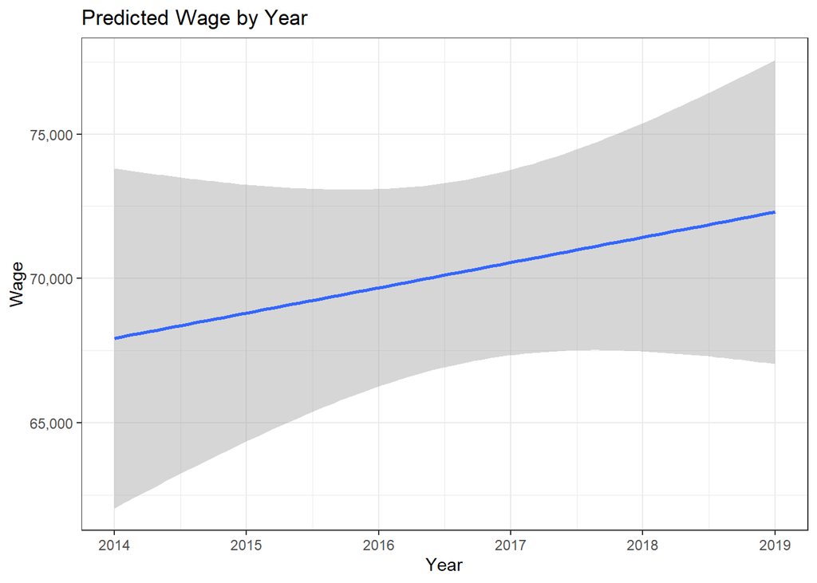

As usual when it comes to wages, the effect is more stable manually than the cause due to employment agreement.

### Conclusion

We evaluated there is no effect of the wildfires cases on firefighters wage. We say this is not necessarily bad.

In my opinion, the intensiveness of the firefighters shifts can by reflected in their salary as a limited bonus. This way, the salary will not by too varied, but hard work will steal be rewarded in the payment. In addition, long term plan of salary that would attract good potential firefighters is a fundamental need for any planned market. otherwise, in a moment of need, the firefighters can just look for another job, like the [CNN told in 2021](https://edition.cnn.com/2021/06/26/us/california-wildfires-hotshot-firefighter-shortage/index.html)